# Practical Machine Learning Project

trungnt

April 15, 2018

## Background

Using devices such as Jawbone Up, Nike FuelBand, and Fitbit it is now possible to collect a large amount of data about personal activity relatively inexpensively. These type of devices are part of the quantified self movement-a group of enthusiasts who take measurements about themselves regularly to improve their health, to find patterns in their behavior, or because they are tech geeks. One thing that people regularly do is quantify how much of a particular activity they do, but they rarely quantify how well they do it. In this project, your goal will be to use data from accelerometers on the belt, forearm, arm, and dumbell of 6 participants. They were asked to perform barbell lifts correctly and incorrectly in 5 different ways. More information is available from the website here: http://groupware.les.inf.puc-rio.br/har (see the section on the Weight Lifting Exercise Dataset)

## Data Processing

1. Load the required packages

```r
library(caret)
library(rpart)
library(rpart.plot)
library(randomForest)
```

2. Loading data set

```r
trainDF <- read.csv("data/pml-training.csv", na.strings = c("NA", ""))
testDF  <- read.csv("data/pml-testing.csv",  na.strings = c("NA", ""))
str(trainDF)
```

```
## 'data.frame':    19622 obs. of  160 variables:
##  $ X                       : int  1 2 3 4 5 6 7 8 9 10 ...
##  $ user_name               : Factor w/ 6 levels "adelmo","carlitos",..: 2 2 2 2 2 2 2 2 2 2 ...
##  $ raw_timestamp_part_1    : int  1323084231 1323084231 1323084231 1323084232 1323084232 1323084232 1323084232 1323084232 1323084232 1323084232 ...
##  $ raw_timestamp_part_2    : int  788290 808298 820366 120339 196328 304277 368296 440390 484323 484434 ...
##  $ cvtd_timestamp          : Factor w/ 20 levels "02/12/2011 13:32",..: 9 9 9 9 9 9 9 9 9 9 ...
##  $ new_window              : Factor w/ 2 levels "no","yes": 1 1 1 1 1 1 1 1 1 1 ...
##  $ num_window              : int  11 11 11 12 12 12 12 12 12 12 ...
##  $ roll_belt               : num  1.41 1.41 1.42 1.48 1.48 1.45 1.42 1.42 1.43 1.45 ...
##  $ pitch_belt              : num  8.07 8.07 8.07 8.05 8.07 8.06 8.09 8.13 8.16 8.17 ...
##  $ yaw_belt                : num  -94.4 -94.4 -94.4 -94.4 -94.4 -94.4 -94.4 -94.4 -94.4 -94.4 ...
##  $ total_accel_belt        : int  3 3 3 3 3 3 3 3 3 3 ...
##  $ kurtosis_roll_belt      : Factor w/ 396 levels "0.000673","0.005503",..: NA NA NA NA NA NA NA NA NA NA ...
##  $ kurtosis_picth_belt     : Factor w/ 316 levels "0.006078","-0.021887",..: NA NA NA NA NA NA NA NA NA NA ...
##  $ kurtosis_yaw_belt       : Factor w/ 1 level "#DIV/0!": NA NA NA NA NA NA NA NA NA NA ...
```

[output cut: 86 more lines]

The training dataset has 19622 observations and 160 variables, and the testing data set contains 20 observations and the same variables as the training set. We are trying to predict the outcome of the variable classe in the training set.

3. Data cleaning

###### Delete columns that contain any missing values

```r
trainDF <- trainDF[, colSums(is.na(trainDF)) == 0]
testDF  <- testDF[, colSums(is.na(testDF)) == 0]
```

###### Delete columns have little predicting power for the outcome $classe$

```r
trainDF <- trainDF[, -c(1:7)]
testDF  <- testDF[, -c(1:7)]
dim(trainDF)
```

```
## [1] 19622    53
```

```r
dim(testDF)
```

```
## [1] 20 53
```

Final, we have train set with 53 columns and 19622 rows, test set has same columns and 20 rows.

4. Split train set  
   We nead split train set into a training set (train, 70%) for prediction and a validation set (valid 30%) to compute the out-of-sample errors.

```r
set.seed(10)
indTrain <- createDataPartition(trainDF$classe, p = 0.7, list = FALSE)
train <- trainDF[indTrain,  ]
valid <- trainDF[-indTrain, ]
```

### Classification with Random forest algorithms

1. Training

```r
control <- trainControl(method = "cv", number = 5)
model_rf <- train(classe ~ ., data = train, method = "rf", trControl = control)
print(model_rf, digits = 4)
```

```
## Random Forest
##
## 13737 samples
##    52 predictors
##     5 classes: 'A', 'B', 'C', 'D', 'E'
##
## No pre-processing
## Resampling: Cross-Validated (5 fold)
## Summary of sample sizes: 10989, 10990, 10989, 10990, 10990
## Resampling results across tuning parameters:
##
##   mtry  Accuracy  Kappa
##    2    0.9906    0.9881
##   27    0.9910    0.9886
##   52    0.9848    0.9808
##
## Accuracy was used to select the optimal model using the largest value.
## The final value used for the model was mtry = 27.
```

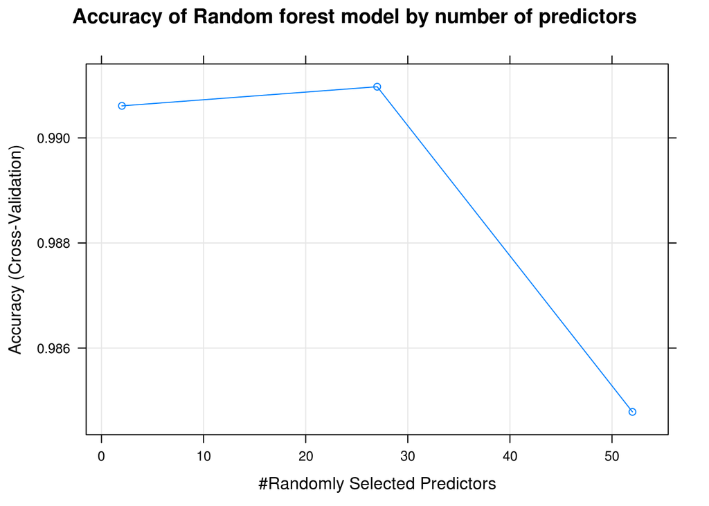

```r
plot(model_rf, main="Accuracy of Random forest model by number of predictors")
```

2. Testing Testing outcomes using validation set

```r
predict_rf <- predict(model_rf, valid)
(conf_rf <- confusionMatrix(valid$classe, predict_rf))
```

```
## Confusion Matrix and Statistics
##
##           Reference
## Prediction    A    B    C    D    E
##          A 1674    0    0    0    0
##          B    7 1125    6    1    0
##          C    0    9 1013    4    0
##          D    0    1    6  957    0
##          E    0    1    2    1 1078
##
## Overall Statistics
##
##                Accuracy : 0.9935
##                  95% CI : (0.9911, 0.9954)
##     No Information Rate : 0.2856
##     P-Value [Acc > NIR] : < 2.2e-16
##
##                   Kappa : 0.9918
##  Mcnemar's Test P-Value : NA
##
## Statistics by Class:
##
##                      Class: A Class: B Class: C Class: D Class: E
## Sensitivity            0.9958   0.9903   0.9864   0.9938   1.0000
## Specificity            1.0000   0.9971   0.9973   0.9986   0.9992
## Pos Pred Value         1.0000   0.9877   0.9873   0.9927   0.9963
## Neg Pred Value         0.9983   0.9977   0.9971   0.9988   1.0000
## Prevalence             0.2856   0.1930   0.1745   0.1636   0.1832
## Detection Rate         0.2845   0.1912   0.1721   0.1626   0.1832
## Detection Prevalence   0.2845   0.1935   0.1743   0.1638   0.1839
## Balanced Accuracy      0.9979   0.9937   0.9918   0.9962   0.9996
```

3. Prediction  
   Use $random forests$ to predict the outcome variable classe for the testing set.

```r
(predict(model_rf, testDF))
```

```
##  [1] B A B A A E D B A A B C B A E E A B B B
## Levels: A B C D E
```